# Act Report

- After storage of the dataset in the 'twitter_archive_master.csv', I went ahead to visualize the data and come up with inisghts. I paused three questions for visualizations and producing insights. Although in the first question, I used df_clean data to plot the piechart.

## 1. What was the most source for most tweets?

- I used the df_clean(twitter_archive) to plot a piechart to show the percentage of the sources of various tweets.

Below is a piechart showing the distribution of the sources of tweets.

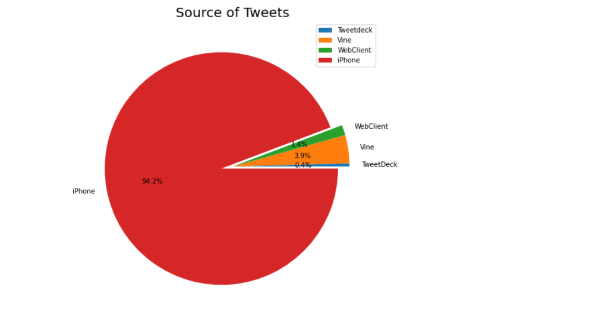

- From the above piechart, iPhone is the source of most tweets followed by Vine. TweetDeck has the least amount of tweets.
- 94.2% of the tweets was posted using iPhone twitter app, and that's probably because the tweets are from @WeRate Dogs account.

Below is a horizontal bar chart showing the stages and their popularity

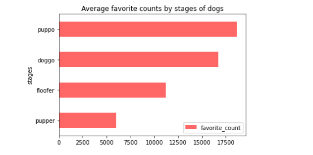

## 3. What is the most popular dog breeds in the dataset?

- I used seaborn to plot the most popular dog breeds by WeRateDogs. I used the dog_breed column.

Below is a bar graph that visualizes the dog_breeds

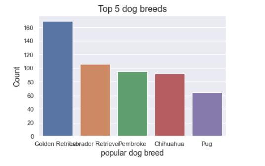

- From the above bar graph,the top 5 most popuar dog breeds by WeRateDogs are Golden Retriever, Labrador Retriver, Pembroke, Chihuahua and pug. The top 1 being the Golden Retriever with it's popularity being almost 2 times that of Pembroke